# D213 Advanced Data Analytics

## Performance Assessment Task 1

### A1: Research Question

Can an ARIMA model be used to produce a forecast of revenue for the next month?

### A2: Goal of Analysis

The goal of this analysis is to create a time series model that is able to create a reasonably accurate forecast of future revenue for the organization. Being able to anticipate future revenues is important for any organization in order to appropriately allocate company resources. For this analysis, we will look to see if a model can be created to forecast the revenue for the next month.

### B: Assumptions of Time Series Analysis

#### Stationarity:

In order to perform a time series analysis using ARIMA, the data must be stationary. For data to be stationary, its statistical properties, such as the mean and standard deivation, must remain constant over time. If you were to look at a visual of stationary data, it would be flat with no upward or downward trend, the variance of the data would be constant, and there would be no repeating seasonal patterns in the data (National Institute of Standards and Technology, n.d.).

#### Autocorrelation

Autocorrelation is a measure of the similarity between a point and a lagged version of itself. In order for a time series analysis to be done, the data can not be autocorrelated. Doing an analysis on data with autocorrelation can lead to erroneous results (Dotis-Georgiou, 2019).

### C1: Line Graph

```python
import pandas as pd #for creating and manipulating DataFrames
import matplotlib.pyplot as plt #for creating visualizations
%matplotlib inline
import warnings #filter out warning messages to keep report looking clean
warnings.filterwarnings('ignore')
```

```python
# read in csv file
df = pd.read_csv('teleco_time_series .csv')
df.columns = df.columns.str.lower() #set column names to all lower case
```

```python
from datetime import datetime
df['date'] = (pd.date_range(start=datetime(2023,1,1), periods=df.shape[0], freq='24H')) #create date column to set to index
```

```python
df.set_index('date', inplace=True) # set date column as index
time = df['revenue'] # create time series with date index and revenue as only column
time.head()
```

```
date
2023-01-01    0.000000
2023-01-02    0.000793
2023-01-03    0.825542
2023-01-04    0.320332
2023-01-05    1.082554
Name: revenue, dtype: float64
```

```python
rolling_mean = time.rolling(30).mean() # calculate rolling mean
rolling_std = time.rolling(30).std() # calculate rolling standard deviation
```

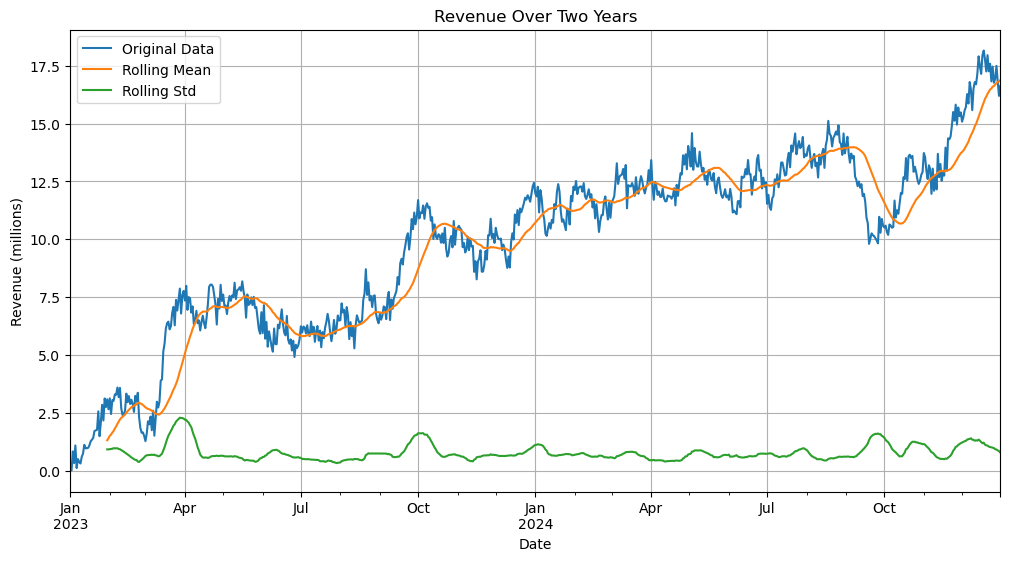

```python
# plot time series with rolling mean and standard deviation
plt.figure(figsize=(12,6))
time.plot(label='Original Data')
rolling_mean.plot(label='Rolling Mean')
rolling_std.plot(label='Rolling Std')
plt.title('Revenue Over Two Years')
plt.xlabel('Date')
plt.ylabel('Revenue (millions)')
plt.legend()
plt.grid()
plt.show()
```

### C2: Time Step Formatting

The time series shows the company's daily revenue over a two year period. Each observation represents the revenue for a that specific date. There are 731 observations in the data which indicates that one of the years was a leap year. The data trends upwards over time with two large spikes in revenue during the first year and a large drop in revenue during the second year followed by a large increase in revenue. There are no gaps in the data.

### C3: Stationarity

Based on a visual inspection of the time series shown in C1, it is highly likely that the data is not stationary. This can be seen in the upward trend of the data. Additionally, the rolling mean and standard deviation on the graph are not constant over time. To confirm this, we will use the Augmented Dickey-Fuller test. The test yields a p-value of 0.32 which means that we accept the null hypothesis and the data is not stationary.

```python
from statsmodels.tsa.stattools import adfuller #check stationarity of data
```

```python
# test data for stationarity and print results
result = adfuller(time)
print('Test Statistic:', result[0])
print('p-value:', result[1])
print('Critical Values:', result[4])
```

```
Test Statistic: -1.9246121573101842
p-value: 0.3205728150793961
Critical Values: {'1%': -3.4393520240470554, '5%': -2.8655128165959236, '10%': -2.5688855736949163}
```

Now that we know that our original data is not stationary, we will take the difference of the data and see if that makes it stationary. Performing the Augmented Dickey-Fuller test on the differenced data doesn't yield a readable p-value. However, when we compare the test statistic to the critical values, we see that the test statistic well below the 5% threshhold, which indicates that our p-value is far below the necessary value of 0.05. Additionally, if we plot the differenced data and visual inspect it, we can see that the data is flat with no upward or downward trend. The data also appears to vary consistantly around the mean. With this we can say that the data is stationary if it is differenced one time. We will use this to set a value of 1 for d when performing our analysis later.

```python
# take the diff one time to see if it makes data stationary
time_diff = time.diff().dropna()
```

```python
result1 = adfuller(time_diff)
print('Test Statistic:', result1[0])
print('p-value:', result1[1])
print('Critical Values:', result1[4])
```

```
Test Statistic: -44.874527193876
p-value: 0.0
Critical Values: {'1%': -3.4393520240470554, '5%': -2.8655128165959236, '10%': -2.5688855736949163}
```

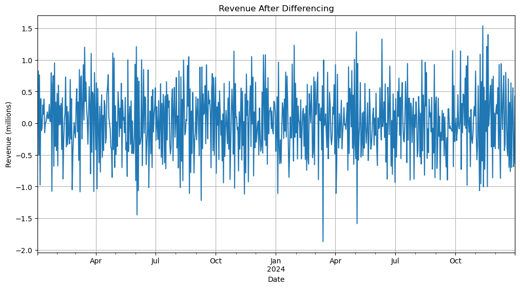

```python
plt.figure(figsize=(12,6))
time_diff.plot()
plt.title('Revenue After Differencing')
plt.xlabel('Date')
plt.ylabel('Revenue (millions)')
plt.grid()
plt.show()
```

### C4: Data Preparation

First, we look at the shape and data type of our data. Then we check for null values using isnull().sum(). This yields a value of zero meaning that we have no null values in our data.

```python
# check shape of data
time.shape
```

```
(731,)
```

```python
# check data types
time.info()
```

```
<class 'pandas.core.series.Series'>
DatetimeIndex: 731 entries, 2023-01-01 to 2024-12-31
Series name: revenue
Non-Null Count  Dtype
--------------  -----
731 non-null    float64
dtypes: float64(1)
memory usage: 11.4 KB
```

```python
# check for null values
time.isnull().sum()
```

```
0
```

Finally, we split the data into training and test sets for our model.

```python
# split into training and test sets
X_train = time.loc[:'2024-11-30']
X_test = time.loc['2024-12-01':]

print('Training Data Shape:', X_train.shape,'\n', 'Test Data Shape:', X_test.shape)
```

```
Training Data Shape: (700,)
 Test Data Shape: (31,)
```

### C5: Cleaned Data Set

```python
# export cleaned data to csv file
#commented out to avoid making multiple copies
#time.to_csv('d213_pa1_data_cjantsch.csv')
```

### D1: Findings and Visualization

```python
from statsmodels.tsa.seasonal import seasonal_decompose
from statsmodels.graphics.tsaplots import plot_acf, plot_pacf
```

```python
# decompose the data
decomp = seasonal_decompose(time, period=7)
```

Plotting the seasonal component of the decomposed time series shows a 7 day seasonal repeating trend in the data.

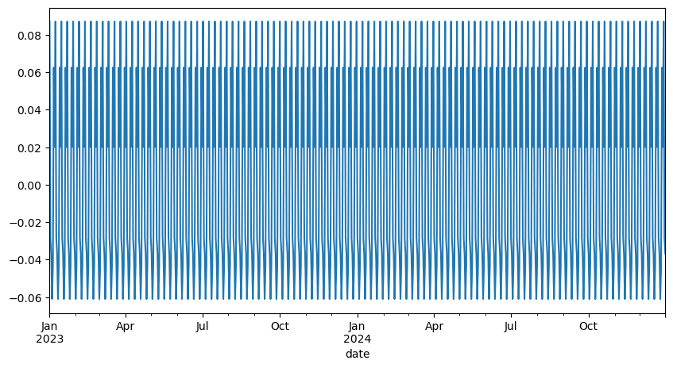

```python
# plot of seasonal component
plt.figure(figsize=(10,5))
decomp.seasonal.plot()
plt.show()
```

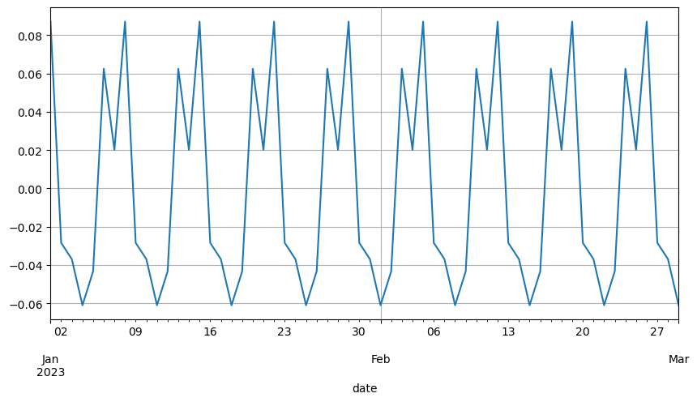

```python
#plot a slice of seasonal component
plt.figure(figsize=(10,5))
decomp.seasonal[:60].plot()
plt.grid()
plt.show()
```

The data has significant ups and downs in the trend line but the overall direction is positive.

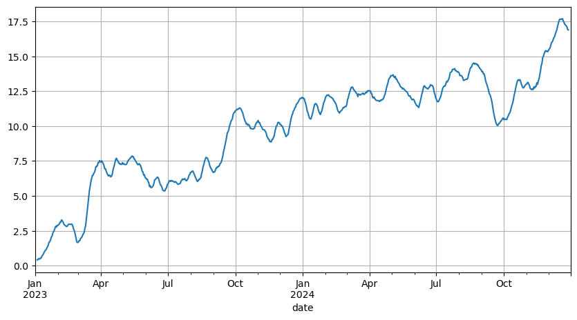

```python
# plot of trend
plt.figure(figsize=(10,5))
decomp.trend.plot()
plt.grid(True)
plt.show()
```

The plots of the acf and pacf show significant autocorrelation at lag 1 for the pacf and the acf graph trails off gradually. This may suggest an AR(1) model. We will look further into this in the following sections.

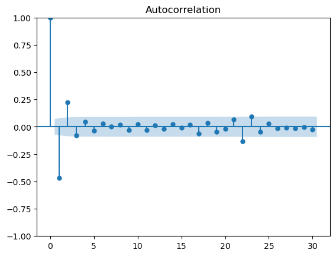

```python
# autocorrelation of the stationary data
plot_acf(time_diff, lags=30)
plt.show()
```

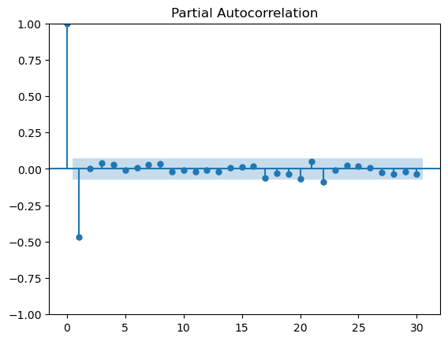

```python
# partial autocorrelation of the stationary data
plot_pacf(time_diff, lags=30)
plt.show()
```

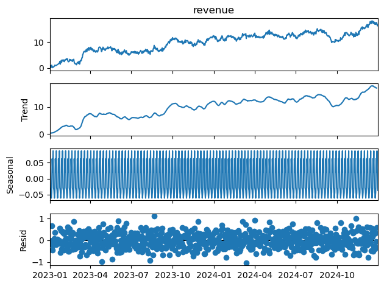

```python
# plot of all decomposed elements
decomp.plot()
plt.show()
```

The acf plot of the residuals from the decomposed time series shows some autocorrelation at lags 1 and 3 but overall there isn't a significant amount of autocorrelation in the residuals. A visual inspection of the residuals doesn't show any signs of repeating patterns and generally resembles white noise.

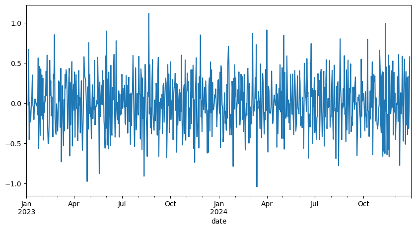

```python
# plot of residuals
plt.figure(figsize=(10,5))
decomp.resid.plot()
plt.show()
```

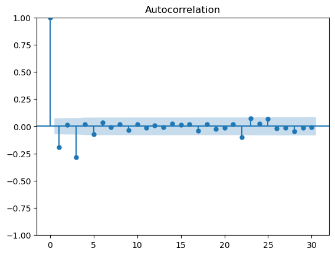

```python
#plot the acf of the residuals
plot_acf(decomp.resid.dropna(), lags=30)
plt.show()
```

### D2: ARIMA Model Parameters

```python
# used to create ARIMA model
from statsmodels.tsa.arima.model import ARIMA
from statsmodels.tsa.statespace.sarimax import SARIMAX
```

```python
from pmdarima import auto_arima #used to determine optimal values for model
```

To find the optimal values for our ARIMA model, we will use auto_arima. Auto_arima will go through and test out various values for our model and compare them using the models AIC values. It returns the model with the lowest AIC score as the best model for the data. Here, it returns an ARIMA(1,1,0) model which is consistent with our previous observations about the stationarity of the data and the acf and pacf plots.

```python
# use auto arima to find best p and q values
test_model = auto_arima(time, d=1, m=7, trace=True, suppress_warnings=True, error_action='ignore')
test_model.summary()
```

```
Performing stepwise search to minimize aic
 ARIMA(2,1,2)(1,0,1)[7] intercept   : AIC=989.282, Time=0.99 sec
 ARIMA(0,1,0)(0,0,0)[7] intercept   : AIC=1162.819, Time=0.05 sec
 ARIMA(1,1,0)(1,0,0)[7] intercept   : AIC=984.241, Time=0.12 sec
 ARIMA(0,1,1)(0,0,1)[7] intercept   : AIC=1020.987, Time=0.16 sec
 ARIMA(0,1,0)(0,0,0)[7]             : AIC=1162.139, Time=0.02 sec
 ARIMA(1,1,0)(0,0,0)[7] intercept   : AIC=983.122, Time=0.06 sec
 ARIMA(1,1,0)(0,0,1)[7] intercept   : AIC=984.271, Time=0.12 sec
 ARIMA(1,1,0)(1,0,1)[7] intercept   : AIC=inf, Time=0.54 sec
 ARIMA(2,1,0)(0,0,0)[7] intercept   : AIC=985.104, Time=0.08 sec
 ARIMA(1,1,1)(0,0,0)[7] intercept   : AIC=985.106, Time=0.06 sec
 ARIMA(0,1,1)(0,0,0)[7] intercept   : AIC=1019.369, Time=0.08 sec
 ARIMA(2,1,1)(0,0,0)[7] intercept   : AIC=986.045, Time=0.33 sec
 ARIMA(1,1,0)(0,0,0)[7]             : AIC=984.710, Time=0.03 sec

Best model:  ARIMA(1,1,0)(0,0,0)[7] intercept
Total fit time: 2.650 seconds
```

SARIMAX Results

| Dep. Variable: | y | No. Observations: | 731 |
| --- | --- | --- | --- |
| Model: | SARIMAX(1, 1, 0) | Log Likelihood | -488.561 |
| Date: | Wed, 28 Aug 2024 | AIC | 983.122 |
| Time: | 13:51:51 | BIC | 996.901 |
| Sample: | 01-01-2023 | HQIC | 988.438 |
|  | - 12-31-2024 |  |  |
| Covariance Type: | opg |  |  |

|  | coef | std err | z | P>\|z\| | [0.025 | 0.975] |
| --- | --- | --- | --- | --- | --- | --- |
| intercept | 0.0332 | 0.018 | 1.895 | 0.058 | -0.001 | 0.068 |
| ar.L1 | -0.4692 | 0.033 | -14.296 | 0.000 | -0.534 | -0.405 |
| sigma2 | 0.2232 | 0.013 | 17.801 | 0.000 | 0.199 | 0.248 |

| Ljung-Box (L1) (Q): | 0.00 | Jarque-Bera (JB): | 2.05 |
| --- | --- | --- | --- |
| Prob(Q): | 0.96 | Prob(JB): | 0.36 |
| Heteroskedasticity (H): | 1.02 | Skew: | -0.02 |
| Prob(H) (two-sided): | 0.85 | Kurtosis: | 2.74 |

Warnings:  
[1] Covariance matrix calculated using the outer product of gradients (complex-step).

To confirm that the output of auto_arima is in fact the model with the lowest AIC score, we will run two for loops to test different p and q values in an ARIMA model and print out the results of the models with AIC scores lower than the previous best iteration. In the end, we confirm our auto_arima results with the code outputting an ARIMA(1,1,0) model as our best model.

```python
# compare results againts an ARIMA model in a for loop
best_aic = 5000

for p in range(6):
    for q in range(6):
        try:
            test_model = ARIMA(time, order=(p, 1, q))
            test_results = test_model.fit()
            if test_results.aic < best_aic:
                best_aic = test_results.aic
                print(p, q, best_aic)
        except:
            continue
```

```
0 0 1162.138886158324
0 1 1021.5939894064513
0 2 987.4269714189304
0 3 987.3120327382953
1 0 984.7100557722092
```

Now we create a model using our training data, generate predictions, and compare those predictions against our test data.

```python
# fit these parameters to an ARIMA model
model_arima = ARIMA(X_train, order=(1,1,0))
results_arima = model_arima.fit()
print(results_arima.summary())
```

```
                               SARIMAX Results
==============================================================================
Dep. Variable:                revenue   No. Observations:                  700
Model:                 ARIMA(1, 1, 0)   Log Likelihood                -466.427
Date:                Wed, 28 Aug 2024   AIC                            936.854
Time:                        13:52:01   BIC                            945.953
Sample:                    01-01-2023   HQIC                           940.371
                         - 11-30-2024
Covariance Type:                  opg
==============================================================================
                 coef    std err          z      P>|z|      [0.025      0.975]
------------------------------------------------------------------------------
ar.L1         -0.4710      0.033    -14.124      0.000      -0.536      -0.406
sigma2         0.2223      0.013     17.609      0.000       0.198       0.247
===================================================================================
Ljung-Box (L1) (Q):                   0.03   Jarque-Bera (JB):                 1.44
Prob(Q):                              0.86   Prob(JB):                         0.49
Heteroskedasticity (H):               0.96   Skew:                            -0.01
Prob(H) (two-sided):                  0.76   Kurtosis:                         2.78
===================================================================================

Warnings:
[1] Covariance matrix calculated using the outer product of gradients (complex-step).
```

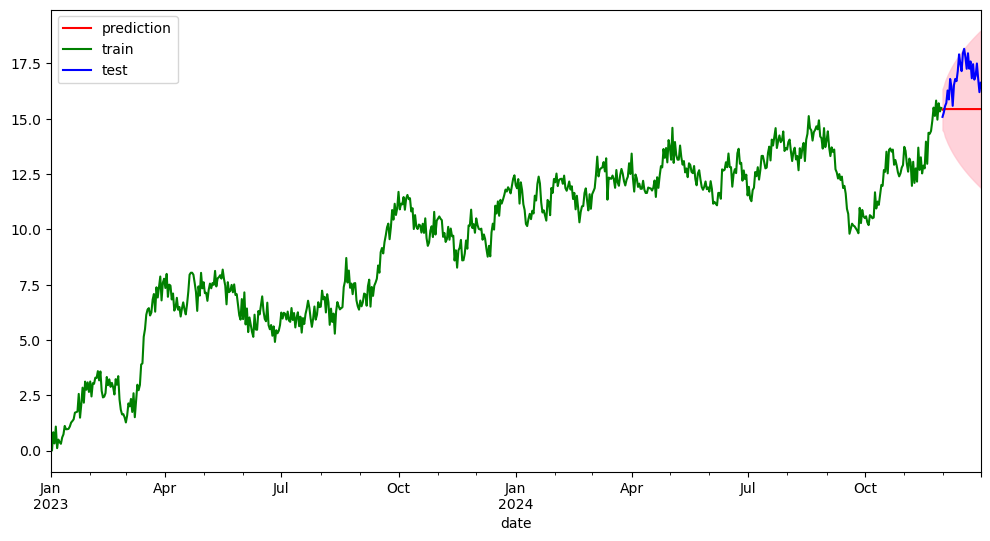

```python
# visualize predictions vs test data
start = len(X_train)
end = len(X_train) + len(X_test) - 1

predictions_arima = results_arima.get_prediction(start, end) #generating predictions
con_int_arima = predictions_arima.conf_int() #confidence intervals
lower = con_int_arima['lower revenue']
upper = con_int_arima['upper revenue']

plt.figure(figsize=(12,6))
predictions_arima.predicted_mean.plot(c='red', legend=True, label='prediction')
X_train.plot(c='green', legend=True, label='train')
X_test.plot(c='blue', legend=True, label='test')
plt.legend(loc='upper left')
plt.fill_between(lower.index, lower, upper, color='pink', alpha=0.7)
plt.show()
```

```python
from sklearn.metrics import mean_squared_error, mean_absolute_error
import numpy as np
```

```python
# inspect the mean of the test data and predicted mean for same period
print('Test Data Mean:', X_test.mean())
print('Prediction Mean', predictions_arima.predicted_mean.mean())
```

```
Test Data Mean: 16.814402340967742
Prediction Mean 15.430079426797159
```

```python
# inspect the root mean squared error and mean absolute error of training model predictions against the test data
rmse = np.sqrt(mean_squared_error(predictions_arima.predicted_mean, X_test))
mae = mean_absolute_error(predictions_arima.predicted_mean, X_test)
print('ARIMA rmse:', rmse)
print('ARIMA mae:', mae)
```

```
ARIMA rmse: 1.6056638488096402
ARIMA mae: 1.4166308566700485
```

### D3: Forecast

```python
# create final model
fin_model = ARIMA(time, order=(1,1,0))
fin_results = fin_model.fit()
fin_results.summary()
```

SARIMAX Results

| Dep. Variable: | revenue | No. Observations: | 731 |
| --- | --- | --- | --- |
| Model: | ARIMA(1, 1, 0) | Log Likelihood | -490.355 |
| Date: | Wed, 28 Aug 2024 | AIC | 984.710 |
| Time: | 13:52:01 | BIC | 993.896 |
| Sample: | 01-01-2023 | HQIC | 988.254 |
|  | - 12-31-2024 |  |  |
| Covariance Type: | opg |  |  |

|  | coef | std err | z | P>\|z\| | [0.025 | 0.975] |
| --- | --- | --- | --- | --- | --- | --- |
| ar.L1 | -0.4667 | 0.033 | -14.213 | 0.000 | -0.531 | -0.402 |
| sigma2 | 0.2243 | 0.013 | 17.782 | 0.000 | 0.200 | 0.249 |

| Ljung-Box (L1) (Q): | 0.00 | Jarque-Bera (JB): | 2.07 |
| --- | --- | --- | --- |
| Prob(Q): | 0.98 | Prob(JB): | 0.36 |
| Heteroskedasticity (H): | 1.02 | Skew: | -0.02 |
| Prob(H) (two-sided): | 0.89 | Kurtosis: | 2.74 |

Warnings:  
[1] Covariance matrix calculated using the outer product of gradients (complex-step).

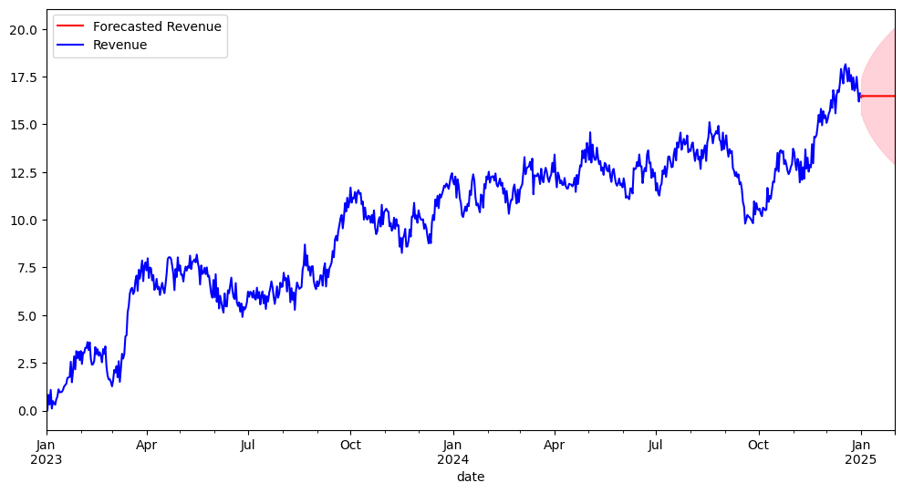

```python
# make future predictions
forecast = fin_results.get_forecast(steps=31)
fore_con_int = forecast.conf_int()
for_lower = fore_con_int['lower revenue']
for_upper = fore_con_int['upper revenue']

plt.figure(figsize=(12,6))
forecast.predicted_mean.plot(c='red', legend=True, label='Forecasted Revenue')
time.plot(c='blue', legend=True, label='Revenue')
plt.fill_between(for_lower.index, for_lower, for_upper, color='pink', alpha=0.7)
plt.legend(loc='upper left')
plt.show()
```

### D4: Output and Calculations

```python
# inspect the mean of the test data and predicted mean for same period
print('Test Data Mean:', X_test.mean())
print('Prediction Mean', predictions_arima.predicted_mean.mean())
```

```
Test Data Mean: 16.814402340967742
Prediction Mean 15.430079426797159
```

```python
# inspect the root mean squared error and mean absolute error of training model predictions against the test data
rmse = np.sqrt(mean_squared_error(predictions_arima.predicted_mean, X_test))
mae = mean_absolute_error(predictions_arima.predicted_mean, X_test)

print('ARIMA rmse:', rmse)
print('ARIMA mae:', mae)
```

```
ARIMA rmse: 1.6056638488096402
ARIMA mae: 1.4166308566700485
```

```python
# predicted values from forecast
print('Mean of Forecast Data:', forecast.predicted_mean.mean(), '\n')
print('Forecast Data:', forecast.predicted_mean)
```

```
Mean of Forecast Data: 16.48386893903615

Forecast Data: 2025-01-01    16.422010
2025-01-02    16.514776
2025-01-03    16.471486
2025-01-04    16.491688
2025-01-05    16.482261
2025-01-06    16.486660
2025-01-07    16.484607
2025-01-08    16.485565
2025-01-09    16.485118
2025-01-10    16.485326
2025-01-11    16.485229
2025-01-12    16.485275
2025-01-13    16.485253
2025-01-14    16.485263
2025-01-15    16.485259
2025-01-16    16.485261
2025-01-17    16.485260
2025-01-18    16.485260
2025-01-19    16.485260
2025-01-20    16.485260
2025-01-21    16.485260
2025-01-22    16.485260
2025-01-23    16.485260
2025-01-24    16.485260
2025-01-25    16.485260
2025-01-26    16.485260
2025-01-27    16.485260
2025-01-28    16.485260
2025-01-29    16.485260
2025-01-30    16.485260
2025-01-31    16.485260
Freq: D, Name: predicted_mean, dtype: float64
```

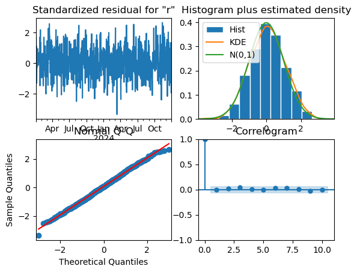

```python
# diagnostics for final model
fin_results.plot_diagnostics()
plt.show()
```

### D5: Code

All supporting code can be found in the above sections.

### E1: Results of Analysis

#### Model Selection

The process for selecting a model is as follows. First, we test the data for stationarity and took the difference of the data to determine the value of d for our ARIMA model. Since we were able to make the data stationary by taking the difference one time, d was set to 1. Next, we put our full data set into auto_arima to determine the p and q values that produced the lowest AIC score. Auto_arima suggested an ARIMA(1,1,0) model and we confirmed that this did produce the lowest AIC scores by testing p and q values in an ARIMA model using two for loops.

#### Predictions and Forecast Length

For this analysis a prediction period of one month and a forecast length of one month were chosen. The reason for choosing these intervals is due to the inherent challenge of predicting the future. The longer the period you try to predict the more errors in the model add up and reduce the usefulness of the model. This can be seen by the large 95% confidence intervals seen in the visualizations of the predictions and forecast. These intervals represent the area in which we are confident that the actual values will lie. Since attempting to forecast a period further out would likely yield inaccurate and unrealiable results, a shorter period of one month was chosen.

#### Model Evaluation

When we look at the diagnostics from our model we can conclude that it is a statistically significant model. A visual inspection of the diagnostics plot in section D4 shows that the residuals of our model are normally distributed and that there is no autocorrelation in the residuals. The normal distribution of the residuals can be in the Q-Q plot on the bottom left of the diagnostics plot and the histogram on the top right. In the Q-Q plot, the residuals follow the red line which indicates that they are normally distributed. In the histogram, we see that the orange line is very similar to the green line which shows a normal distribution. The lack of autocorrelation can be seen in acf plot on the bottom right of the plot and the plot of the residuals on the top left. In the acf plot, we see that the autocorrelation values are all in the 95% confidence interval, meaning that they do not vary significantly from zero. In the plot of the residuals, we see that the residuals resemble white noise with no observable patterns. These conclusions are further supported by the p-values for the Ljung-Box and Jarque-Bera test seen in the results summary of the model. The Ljung-Box test has a p-value of 0.98 which means we can accept the null hypothesis that the residuals are not autocorrelated. The Jarque-Bera test has a p-value of 0.36 which means we can accept the null hypothesis that the residuals are normally distributed.

However, while our diagnostics show that our model is statistically significant, a visual inspection of our forecast along with the root mean squared error and mean absolute error of our training model indicate that it may not be practically useful. Looking at the plots for the predictions of our training model and the forecast of our final model, we see that our prediction is just a horizontal line with large 95% confidence intervals. In the training predictions versus test data plot seen in section E2, we see that while the test data lies entirely within the 95% confidence interval, the predicted values do not follow the upward or downward movement of the actual data. This can be seen in the rather large values for the root mean squared error and the mean absolute error. The RMSE had a value of 1.61 and the MAE had a value of 1.42. This means that the actual values of the data will likely differ greatly from our predicted values. This lack of precision means that our model does not offer much value from a practical business standpoint.

### E2: Visualization Comparing Forecast and Test Set

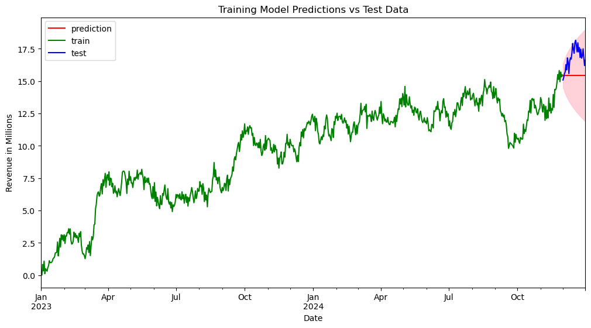

```python
# visualize predictions vs test data
start = len(X_train)
end = len(X_train) + len(X_test) - 1

predictions_arima = results_arima.get_prediction(start, end) #generating predictions
con_int_arima = predictions_arima.conf_int() #confidence intervals
lower = con_int_arima['lower revenue']
upper = con_int_arima['upper revenue']

plt.figure(figsize=(12,6))
predictions_arima.predicted_mean.plot(c='red', legend=True, label='prediction')
X_train.plot(c='green', legend=True, label='train')
X_test.plot(c='blue', legend=True, label='test')
plt.legend(loc='upper left')
plt.fill_between(lower.index, lower, upper, color='pink', alpha=0.7)
plt.xlabel('Date')
plt.ylabel('Revenue in Millions')
plt.title('Training Model Predictions vs Test Data')
plt.show()
```

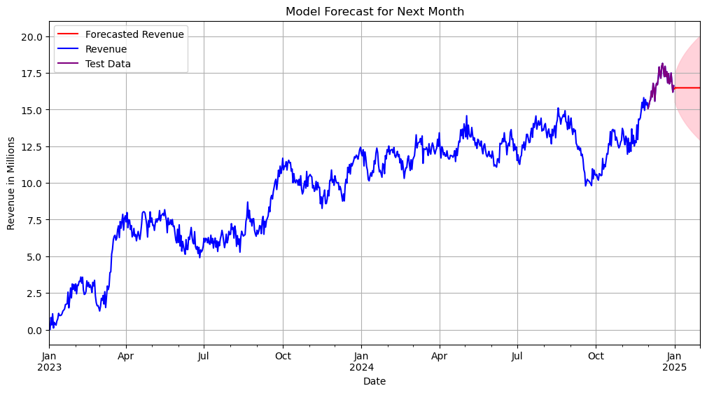

```python
#visualization of forecasted data with original data
plt.figure(figsize=(12,6))
forecast.predicted_mean.plot(c='red', legend=True, label='Forecasted Revenue')
time.plot(c='blue', legend=True, label='Revenue')
X_test.plot(c='purple', legend=True, label='Test Data')
plt.fill_between(for_lower.index, for_lower, for_upper, color='pink', alpha=0.7)
plt.legend(loc='upper left')
plt.xlabel('Date')
plt.ylabel('Revenue in Millions')
plt.title('Model Forecast for Next Month')
plt.grid()
plt.show()
```

### E3: Recommendations

In section E1, we concluded that our model was not practically useful for providing business insight. However, there is the possibility that additional variables could provide the additional information we need to create a useful model. In the plot of our time series, we observe three events in the data that could prove useful if we are able to find their underlying cause. These events are the large increases in revenue seen in March and September 2023 and the large drop followed by a large increase in revenue beginning in August 2024. If we are able to find some other variable that is able to explain these events, we may be able to produce a practically useful model for predicting future revenue. Therefore, it is our recommendation that we look into further understanding these large changes in revenue for potentially useful insights.

### G: Code Sources

No code sources were used for this analysis.

### H: Text Sources

Dotis-Georgiou, A. (2019, May 02). *Autocorrelation in Time Series Data*. InfluxData. https://www.influxdata.com/blog/autocorrelation-in-time-series-data/

National Institute of Standards and Technology (n.d.). *Stationarity*. National Institute of Standards and Technology. https://www.itl.nist.gov/div898/handbook/pmc/section4/pmc442.htm